# W3cubDocs

/Statsmodels

# Autoregressive Moving Average (ARMA): Sunspots data

```
%matplotlib inline

from __future__ import print_function
import numpy as np
from scipy import stats
import pandas as pd
import matplotlib.pyplot as plt

import statsmodels.api as sm
```

```
from statsmodels.graphics.api import qqplot
```

## Sunpots Data

```
print(sm.datasets.sunspots.NOTE)
```

```
::

    Number of Observations - 309 (Annual 1700 - 2008)
    Number of Variables - 1
    Variable name definitions::

        SUNACTIVITY - Number of sunspots for each year

    The data file contains a 'YEAR' variable that is not returned by load.
```

```
dta = sm.datasets.sunspots.load_pandas().data
```

```
dta.index = pd.Index(sm.tsa.datetools.dates_from_range('1700', '2008'))
del dta["YEAR"]
```

```
dta.plot(figsize=(12,8));
```

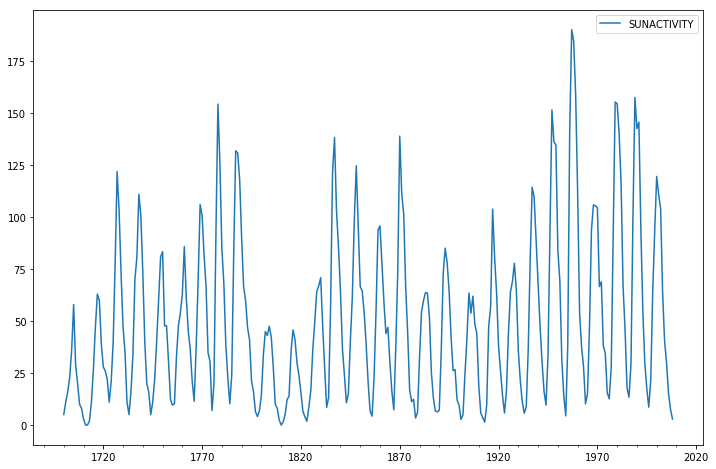

```
fig = plt.figure(figsize=(12,8))
ax1 = fig.add_subplot(211)
fig = sm.graphics.tsa.plot_acf(dta.values.squeeze(), lags=40, ax=ax1)
ax2 = fig.add_subplot(212)
fig = sm.graphics.tsa.plot_pacf(dta, lags=40, ax=ax2)
```

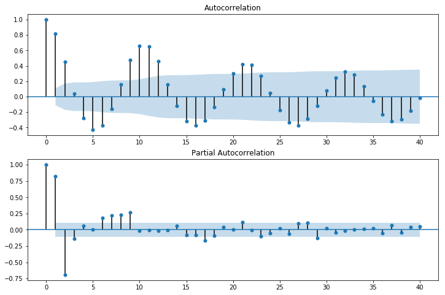

```
arma_mod20 = sm.tsa.ARMA(dta, (2,0)).fit(disp=False)
print(arma_mod20.params)
```

```
const                49.659542
ar.L1.SUNACTIVITY     1.390656
ar.L2.SUNACTIVITY    -0.688571
dtype: float64
```

```
arma_mod30 = sm.tsa.ARMA(dta, (3,0)).fit(disp=False)
print(arma_mod20.aic, arma_mod20.bic, arma_mod20.hqic)
```

```
2622.636338065809 2637.5697031734 2628.606725911055
```

```
print(arma_mod30.params)
```

```
const                49.749936
ar.L1.SUNACTIVITY     1.300810
ar.L2.SUNACTIVITY    -0.508093
ar.L3.SUNACTIVITY    -0.129650
dtype: float64
```

```
print(arma_mod30.aic, arma_mod30.bic, arma_mod30.hqic)
```

```
2619.4036286964474 2638.0703350809363 2626.866613503005
```

- Does our model obey the theory?

```
sm.stats.durbin_watson(arma_mod30.resid.values)
```

```
1.9564807635787604
```

```
fig = plt.figure(figsize=(12,8))
ax = fig.add_subplot(111)
ax = arma_mod30.resid.plot(ax=ax);
```

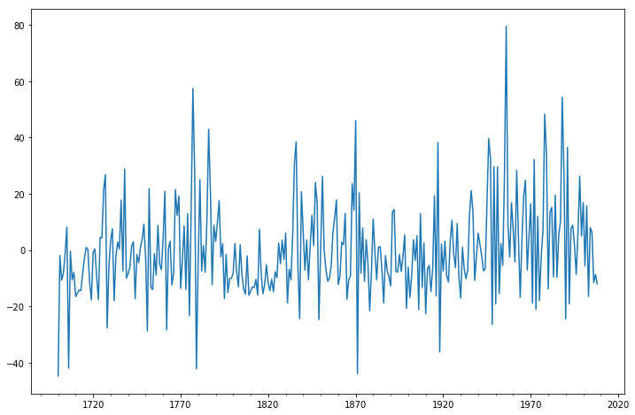

```
resid = arma_mod30.resid
```

```
stats.normaltest(resid)
```

```
NormaltestResult(statistic=49.845019661107585, pvalue=1.5006917858823576e-11)
```

```
fig = plt.figure(figsize=(12,8))
ax = fig.add_subplot(111)
fig = qqplot(resid, line='q', ax=ax, fit=True)
```

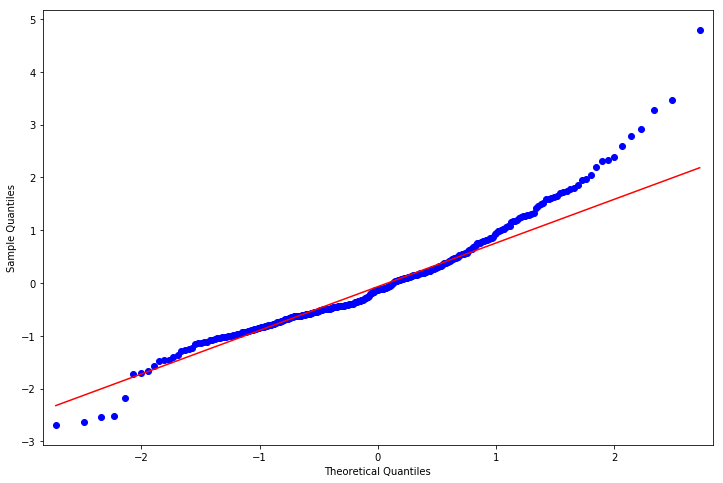

```
fig = plt.figure(figsize=(12,8))
ax1 = fig.add_subplot(211)
fig = sm.graphics.tsa.plot_acf(resid.values.squeeze(), lags=40, ax=ax1)
ax2 = fig.add_subplot(212)
fig = sm.graphics.tsa.plot_pacf(resid, lags=40, ax=ax2)
```

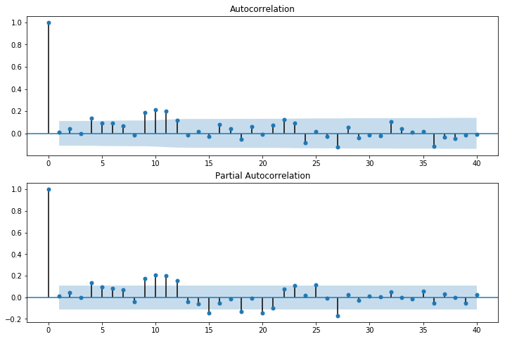

```
r,q,p = sm.tsa.acf(resid.values.squeeze(), qstat=True)
data = np.c_[range(1,41), r[1:], q, p]
table = pd.DataFrame(data, columns=['lag', "AC", "Q", "Prob(>Q)"])
print(table.set_index('lag'))
```

```
            AC          Q      Prob(>Q)
lag
1.0   0.009179   0.026287  8.712023e-01
2.0   0.041793   0.573041  7.508717e-01
3.0  -0.001335   0.573600  9.024484e-01
4.0   0.136089   6.408927  1.706199e-01
5.0   0.092468   9.111841  1.046855e-01
6.0   0.091948  11.793261  6.674304e-02
7.0   0.068748  13.297220  6.518940e-02
8.0  -0.015020  13.369248  9.976074e-02
9.0   0.187592  24.641927  3.393887e-03
10.0  0.213718  39.322013  2.229457e-05
11.0  0.201082  52.361156  2.344931e-07
12.0  0.117182  56.804207  8.574192e-08
13.0 -0.014055  56.868344  1.893888e-07
14.0  0.015398  56.945583  3.997628e-07
15.0 -0.024967  57.149337  7.741415e-07
16.0  0.080916  59.296791  6.872107e-07
17.0  0.041138  59.853761  1.110934e-06
18.0 -0.052021  60.747450  1.548419e-06
19.0  0.062496  62.041713  1.831628e-06
20.0 -0.010301  62.077000  3.381216e-06
21.0  0.074453  63.926674  3.193563e-06
22.0  0.124955  69.154790  8.978292e-07
23.0  0.093162  72.071053  5.799744e-07
24.0 -0.082152  74.346705  4.712985e-07
25.0  0.015695  74.430061  8.288987e-07
26.0 -0.025037  74.642919  1.367275e-06
27.0 -0.125861  80.041162  3.722546e-07
28.0  0.053225  81.009996  4.716253e-07
29.0 -0.038693  81.523822  6.916596e-07
30.0 -0.016904  81.622241  1.151655e-06
31.0 -0.019296  81.750954  1.868756e-06
32.0  0.104990  85.575078  8.927916e-07
33.0  0.040086  86.134579  1.247503e-06
34.0  0.008829  86.161822  2.047816e-06
35.0  0.014588  86.236459  3.263793e-06
36.0 -0.119329  91.248909  1.084450e-06
37.0 -0.036665  91.723876  1.521917e-06
38.0 -0.046193  92.480525  1.938728e-06
39.0 -0.017768  92.592893  2.990669e-06
40.0 -0.006220  92.606716  4.696967e-06
```

- This indicates a lack of fit.
- In-sample dynamic prediction. How good does our model do?

```
predict_sunspots = arma_mod30.predict('1990', '2012', dynamic=True)
print(predict_sunspots)
```

```
1990-12-31    167.047417
1991-12-31    140.993002
1992-12-31     94.859112
1993-12-31     46.860896
1994-12-31     11.242577
1995-12-31     -4.721303
1996-12-31     -1.166920
1997-12-31     16.185687
1998-12-31     39.021884
1999-12-31     59.449878
2000-12-31     72.170152
2001-12-31     75.376793
2002-12-31     70.436464
2003-12-31     60.731586
2004-12-31     50.201791
2005-12-31     42.076018
2006-12-31     38.114277
2007-12-31     38.454635
2008-12-31     41.963810
2009-12-31     46.869285
2010-12-31     51.423261
2011-12-31     54.399720
2012-12-31     55.321692
Freq: A-DEC, dtype: float64
```

```
fig, ax = plt.subplots(figsize=(12, 8))
ax = dta.loc['1950':].plot(ax=ax)
fig = arma_mod30.plot_predict('1990', '2012', dynamic=True, ax=ax, plot_insample=False)
```

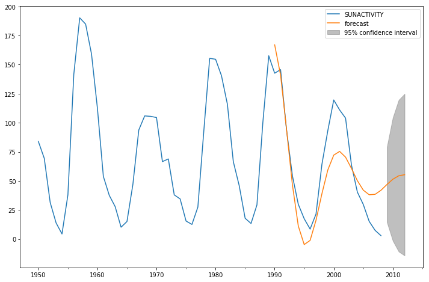

```
def mean_forecast_err(y, yhat):
    return y.sub(yhat).mean()
```

```
mean_forecast_err(dta.SUNACTIVITY, predict_sunspots)
```

```
5.636960215843405
```

### Exercise: Can you obtain a better fit for the Sunspots model? (Hint: sm.tsa.AR has a method select_order)

### Simulated ARMA(4,1): Model Identification is Difficult

```
from statsmodels.tsa.arima_process import arma_generate_sample, ArmaProcess
```

```
np.random.seed(1234)
# include zero-th lag
arparams = np.array([1, .75, -.65, -.55, .9])
maparams = np.array([1, .65])
```

Let's make sure this model is estimable.

```
arma_t = ArmaProcess(arparams, maparams)
```

```
arma_t.isinvertible
```

```
True
```

```
arma_t.isstationary
```

```
False
```

- What does this mean?

```
fig = plt.figure(figsize=(12,8))
ax = fig.add_subplot(111)
ax.plot(arma_t.generate_sample(nsample=50));
```

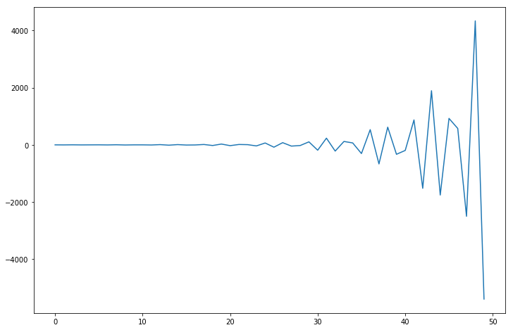

```
arparams = np.array([1, .35, -.15, .55, .1])
maparams = np.array([1, .65])
arma_t = ArmaProcess(arparams, maparams)
arma_t.isstationary
```

```
True
```

```
arma_rvs = arma_t.generate_sample(nsample=500, burnin=250, scale=2.5)
```

```
fig = plt.figure(figsize=(12,8))
ax1 = fig.add_subplot(211)
fig = sm.graphics.tsa.plot_acf(arma_rvs, lags=40, ax=ax1)
ax2 = fig.add_subplot(212)
fig = sm.graphics.tsa.plot_pacf(arma_rvs, lags=40, ax=ax2)
```

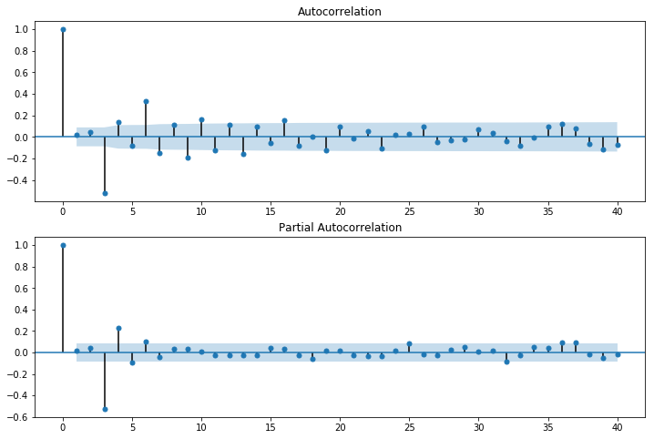

- For mixed ARMA processes the Autocorrelation function is a mixture of exponentials and damped sine waves after (q-p) lags.
- The partial autocorrelation function is a mixture of exponentials and dampened sine waves after (p-q) lags.

```
arma11 = sm.tsa.ARMA(arma_rvs, (1,1)).fit(disp=False)
resid = arma11.resid
r,q,p = sm.tsa.acf(resid, qstat=True)
data = np.c_[range(1,41), r[1:], q, p]
table = pd.DataFrame(data, columns=['lag', "AC", "Q", "Prob(>Q)"])
print(table.set_index('lag'))
```

```
            AC           Q      Prob(>Q)
lag
1.0   0.254921   32.687669  1.082216e-08
2.0  -0.172416   47.670733  4.450737e-11
3.0  -0.420945  137.159383  1.548473e-29
4.0  -0.046875  138.271291  6.617736e-29
5.0   0.103240  143.675896  2.958739e-29
6.0   0.214864  167.132989  1.823728e-33
7.0  -0.000889  167.133391  1.009211e-32
8.0  -0.045418  168.185742  3.094851e-32
9.0  -0.061445  170.115792  5.837244e-32
10.0  0.034623  170.729845  1.958746e-31
11.0  0.006351  170.750546  8.267093e-31
12.0 -0.012882  170.835899  3.220248e-30
13.0 -0.053959  172.336537  6.181225e-30
14.0 -0.016606  172.478955  2.160225e-29
15.0  0.051742  173.864477  4.089565e-29
16.0  0.078917  177.094270  3.217951e-29
17.0 -0.001834  177.096018  1.093173e-28
18.0 -0.101604  182.471927  3.103838e-29
19.0 -0.057342  184.187761  4.624089e-29
20.0  0.026975  184.568275  1.235677e-28
21.0  0.062359  186.605952  1.530266e-28
22.0 -0.009400  186.652354  4.548216e-28
23.0 -0.068037  189.088173  4.562034e-28
24.0 -0.035566  189.755190  9.901143e-28
25.0  0.095679  194.592612  3.354304e-28
26.0  0.065650  196.874866  3.487639e-28
27.0 -0.018404  197.054602  9.008792e-28
28.0 -0.079244  200.393998  5.773739e-28
29.0  0.008499  200.432491  1.541393e-27
30.0  0.053372  201.953764  2.133202e-27
31.0  0.074816  204.949384  1.550168e-27
32.0 -0.071187  207.667232  1.262293e-27
33.0 -0.088145  211.843145  5.480841e-28
34.0 -0.025283  212.187439  1.215233e-27
35.0  0.125690  220.714889  8.231642e-29
36.0  0.142724  231.734107  1.923091e-30
37.0  0.095768  236.706149  5.937808e-31
38.0 -0.084744  240.607793  2.890898e-31
39.0 -0.150126  252.878971  3.963021e-33
40.0 -0.083767  256.707729  1.996181e-33
```

```
arma41 = sm.tsa.ARMA(arma_rvs, (4,1)).fit(disp=False)
resid = arma41.resid
r,q,p = sm.tsa.acf(resid, qstat=True)
data = np.c_[range(1,41), r[1:], q, p]
table = pd.DataFrame(data, columns=['lag', "AC", "Q", "Prob(>Q)"])
print(table.set_index('lag'))
```

```
            AC          Q  Prob(>Q)
lag
1.0  -0.007889   0.031302  0.859569
2.0   0.004132   0.039906  0.980245
3.0   0.018103   0.205415  0.976710
4.0  -0.006760   0.228538  0.993948
5.0   0.018120   0.395024  0.995466
6.0   0.050688   1.700447  0.945087
7.0   0.010252   1.753954  0.972197
8.0  -0.011206   1.818017  0.986092
9.0   0.020292   2.028518  0.991009
10.0  0.001029   2.029060  0.996113
11.0 -0.014035   2.130167  0.997984
12.0 -0.023858   2.422925  0.998427
13.0 -0.002108   2.425216  0.999339
14.0 -0.018783   2.607429  0.999590
15.0  0.011316   2.673698  0.999805
16.0  0.042159   3.595419  0.999443
17.0  0.007943   3.628205  0.999734
18.0 -0.074311   6.503855  0.993686
19.0 -0.023379   6.789067  0.995256
20.0  0.002398   6.792073  0.997313
21.0  0.000487   6.792198  0.998516
22.0  0.017952   6.961435  0.999024
23.0 -0.038576   7.744466  0.998744
24.0 -0.029816   8.213249  0.998859
25.0  0.077850  11.415824  0.990675
26.0  0.040408  12.280448  0.989479
27.0 -0.018612  12.464275  0.992262
28.0 -0.014764  12.580187  0.994586
29.0  0.017650  12.746191  0.996111
30.0 -0.005486  12.762264  0.997504
31.0  0.058256  14.578546  0.994614
32.0 -0.040840  15.473085  0.993887
33.0 -0.019493  15.677311  0.995393
34.0  0.037269  16.425466  0.995214
35.0  0.086212  20.437449  0.976296
36.0  0.041271  21.358847  0.974774
37.0  0.078704  24.716879  0.938948
38.0 -0.029729  25.197056  0.944895
39.0 -0.078397  28.543388  0.891179
40.0 -0.014466  28.657578  0.909268
```

### Exercise: How good of in-sample prediction can you do for another series, say, CPI

```
macrodta = sm.datasets.macrodata.load_pandas().data
macrodta.index = pd.Index(sm.tsa.datetools.dates_from_range('1959Q1', '2009Q3'))
cpi = macrodta["cpi"]
```

#### Hint:

```
fig = plt.figure(figsize=(12,8))
ax = fig.add_subplot(111)
ax = cpi.plot(ax=ax);
ax.legend();
```

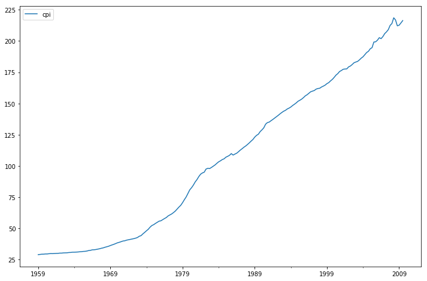

```
print(sm.tsa.adfuller(cpi)[1])
```

```
0.990432818833742
```

© 2009–2012 Statsmodels Developers  
© 2006–2008 Scipy Developers  
© 2006 Jonathan E. Taylor  
Licensed under the 3-clause BSD License.  
http://www.statsmodels.org/stable/examples/notebooks/generated/tsa_arma_0.html